# Imbalanced Classification Tasks

Ignacio Vellido Expósito

18/01/2021

# Activity 1

## Loading the dataset

```r
# load the CSV file from the local or web directory
dataset <- read.csv("subclus.csv", header = FALSE, stringsAsFactors = T)

# set the column names in the dataset (you must know them a priori)
colnames(dataset) <- c("Att1", "Att2", "Class")

dataset$Class <- relevel(dataset$Class,"positive") #to ensure it appears at the first class

dataset
```

| Att1 | Att2 | Class |
| --- | --- | --- |
| 148 | 50 | positive |
| 187 | 34 | positive |
| 290 | -57 | positive |
| 194 | -80 | positive |
| 204 | 89 | positive |
| 196 | -81 | positive |
| 201 | -17 | positive |
| 289 | 4 | positive |
| 116 | -95 | positive |
| 199 | 38 | positive |

[output cut: 590 more lines]

## Summarizing and visualizing

Dimensions (600 rows, 2 attributes, 1 class)

```r
dim(dataset)
```

```
[1] 600   3
```

Types (numeric integer attributes)

```r
str(dataset)
```

```
'data.frame':   600 obs. of  3 variables:
 $ Att1 : int  148 187 290 194 204 196 201 289 116 199 ...
 $ Att2 : int  50 34 -57 -80 89 -81 -17 4 -95 38 ...
 $ Class: Factor w/ 2 levels "positive","negative": 1 1 1 1 1 1 1 1 1 1 ...
```

First rows

```r
head(dataset)
```

|  | Att1 | Att2 | Class |
| --- | --- | --- | --- |
| 1 | 148 | 50 | positive |
| 2 | 187 | 34 | positive |
| 3 | 290 | -57 | positive |
| 4 | 194 | -80 | positive |
| 5 | 204 | 89 | positive |
| 6 | 196 | -81 | positive |

Binary class

```r
levels(dataset$Class)
```

```
[1] "positive" "negative"
```

Statistical summary

```r
summary(dataset)

cat("\nImbalance ratio: ")
imbalanceRatio(dataset)
```

```
      Att1             Att2             Class
 Min.   :-84.00   Min.   :-282.0   positive:100
 1st Qu.: 65.75   1st Qu.: 155.8   negative:500
 Median :213.00   Median : 572.5
 Mean   :214.06   Mean   : 574.5
 3rd Qu.:365.50   3rd Qu.: 961.2
 Max.   :483.00   Max.   :1481.0

Imbalance ratio: [1] 0.2
```

Split input and output

```r
x <- dataset[,1:2]
y <- dataset[,3]
```

Pie chart

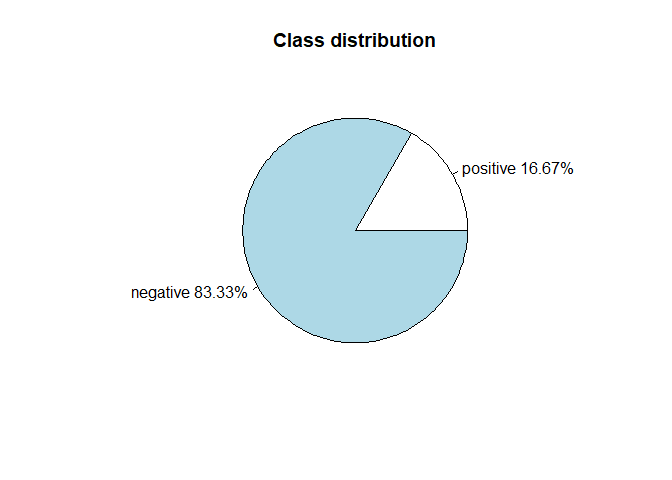

```r
n_classes <- c(sum(y=="positive"),sum(y=="negative"))
pct <- round(n_classes/sum(n_classes)*100,digits=2)

# lbls <- levels(dataset$Class)
lbls <- c("positive", "negative")
lbls <- paste(lbls, pct) # add percents to labels
lbls <- paste(lbls,"%",sep="") # ad % to labels

pie(n_classes,labels = lbls, main="Class distribution")
```

Univariate plots

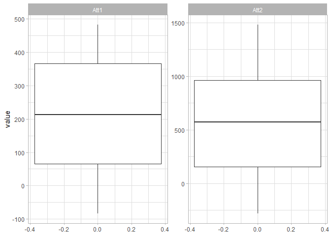

```r
dataset %>%
  pivot_longer(c('Att1','Att2')) %>%
  ggplot(aes(y=value)) +
    geom_boxplot() +
    facet_wrap(~ name, scales = "free") +
    theme_light()
```

Multivariate plots

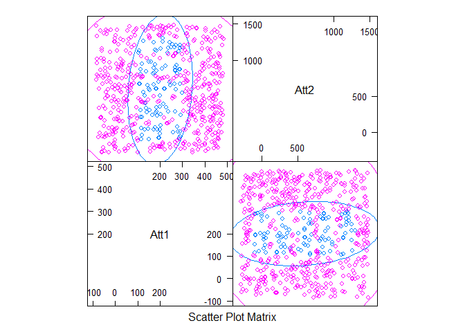

```r
# scatterplot matrix
featurePlot(x=x, y=y, plot="ellipse")
```

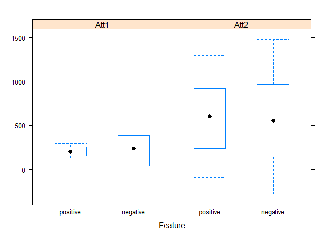

```r
# box and whisker plots for each attribute
featurePlot(x=x, y=y, plot="box")
```

```r
# Dataset scatter plot
dataset %>% ggvis(~Att1, ~Att2, fill = ~Class) %>% layer_points()
```

[output not shown]

Vemos fronteras difusas y clases superpuestas. Imposible de encontrar separación lineal. Modelos basados en vecinos cercanos tendrán problemas si no limpiamos previamente las fronteras. Una vez hecho, podrían funcionar bastante bien.

## Execution and evaluation of models

Create test set with same imbalance ratio

```r
set.seed(42) #To ensure the same output

#An easy way to create split "data partitions":
trainIndex <- createDataPartition(dataset$Class, p = .75,
                                  list = FALSE,
                                  times = 1)
trainData <- dataset[ trainIndex,]
testData  <- dataset[-trainIndex,]

#Check IR to ensure a stratified partition
imbalanceRatio(trainData)
imbalanceRatio(testData)
```

```
[1] 0.2
[1] 0.2
```

Define functions for learning and predict

```r
# a) Learning function
learn_model <-function(dataset, ctrl,message){
  model.fit <- train(Class ~ ., data = dataset, method = "knn",
                   trControl = ctrl, preProcess = c("center","scale"), metric="ROC",
                   tuneGrid = expand.grid(k = c(1,3,5,7,9,11)))
  model.pred <- predict(model.fit,newdata = dataset)
  #Get the confusion matrix to see accuracy value and other parameter values
  model.cm <- confusionMatrix(model.pred, dataset$Class,positive = "positive")
  model.probs <- predict(model.fit,newdata = dataset, type="prob")
  model.roc <- roc(dataset$Class,model.probs[,"positive"],color="green")
  return(model.fit)
}

# b) Estimation function
test_model <-function(dataset, model.fit,message){
  model.pred <- predict(model.fit,newdata = dataset)
  #Get the confusion matrix to see accuracy value and other parameter values
  model.cm <- confusionMatrix(model.pred, dataset$Class,positive = "positive")
  print(model.cm)
  model.probs <- predict(model.fit,newdata = dataset, type="prob")
  model.roc <- roc(dataset$Class,model.probs[,"positive"])
  #print(knn.roc)
  plot(model.roc, type="S", print.thres= 0.5,main=c("ROC Test",message),col="blue")
  #print(paste0("AUC Test ",message,auc(model.roc)))
  return(model.cm)
}
```

Train with raw data

```r
#Execute model ("raw" data)
ctrl <- trainControl(method="repeatedcv",number=5,repeats = 3,
                     classProbs=TRUE,summaryFunction = twoClassSummary)
model.raw <- learn_model(trainData,ctrl,"RAW ")
print(model.raw)
```

```
k-Nearest Neighbors

450 samples
  2 predictor
  2 classes: 'positive', 'negative'

Pre-processing: centered (2), scaled (2)
Resampling: Cross-Validated (5 fold, repeated 3 times)
Summary of sample sizes: 360, 360, 360, 360, 360, 360, ...
Resampling results across tuning parameters:

  k   ROC        Sens       Spec
   1  0.8444444  0.7288889  0.9600000
   3  0.9272000  0.7022222  0.9528889
   5  0.9497185  0.6755556  0.9564444
   7  0.9385481  0.6088889  0.9484444
   9  0.9315556  0.5644444  0.9368889
  11  0.9293333  0.4977778  0.9351111

ROC was used to select the optimal model using the largest value.
The final value used for the model was k = 5.
```

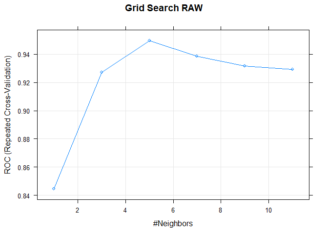

```r
#We may decide to plot the results from the grid search of the model's parameters
plot(model.raw,main="Grid Search RAW")
```

```r
cm.raw <- test_model(testData,model.raw,"RAW ")
```

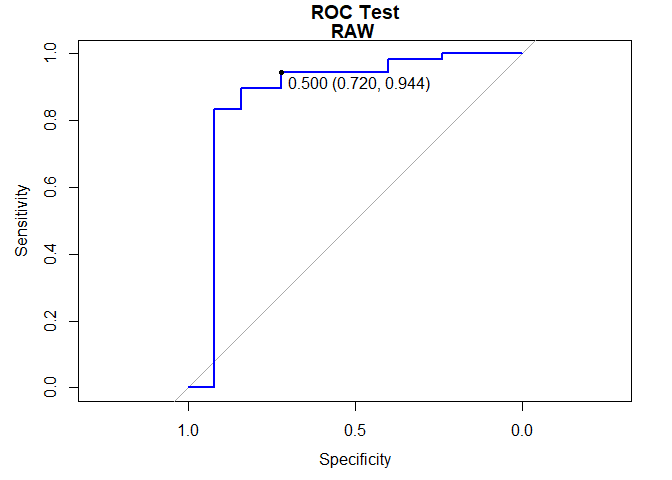

```
Confusion Matrix and Statistics

          Reference
Prediction positive negative
  positive       18        7
  negative        7      118

               Accuracy : 0.9067
                 95% CI : (0.8484, 0.948)
    No Information Rate : 0.8333
    P-Value [Acc > NIR] : 0.007464

                  Kappa : 0.664

 Mcnemar's Test P-Value : 1.000000

            Sensitivity : 0.7200
            Specificity : 0.9440
         Pos Pred Value : 0.7200
         Neg Pred Value : 0.9440
             Prevalence : 0.1667
         Detection Rate : 0.1200
   Detection Prevalence : 0.1667
      Balanced Accuracy : 0.8320

       'Positive' Class : positive
```

Train with Random Undersampling

```r
ctrl <- trainControl(method="repeatedcv",number=5,repeats = 3,
                     classProbs=TRUE,summaryFunction = twoClassSummary,sampling = "down")

model.us <- learn_model(trainData,ctrl,"US ")
cm.us <- test_model(testData,model.us,"US ")
```

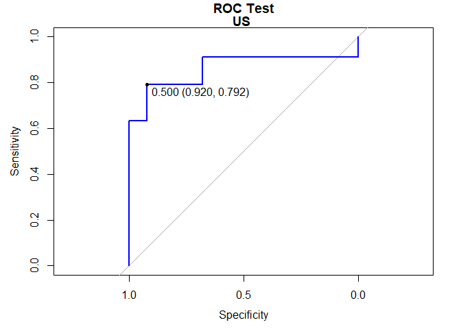

```
Confusion Matrix and Statistics

          Reference
Prediction positive negative
  positive       23       26
  negative        2       99

               Accuracy : 0.8133
                 95% CI : (0.7416, 0.8722)
    No Information Rate : 0.8333
    P-Value [Acc > NIR] : 0.7814

                  Kappa : 0.5145

 Mcnemar's Test P-Value : 1.383e-05

            Sensitivity : 0.9200
            Specificity : 0.7920
         Pos Pred Value : 0.4694
         Neg Pred Value : 0.9802
             Prevalence : 0.1667
         Detection Rate : 0.1533
   Detection Prevalence : 0.3267
      Balanced Accuracy : 0.8560

       'Positive' Class : positive
```

Train with Random Oversamping

```r
ctrl <- trainControl(method="repeatedcv",number=5,repeats = 3,
                     classProbs=TRUE,summaryFunction = twoClassSummary,sampling = "up")
model.os <- learn_model(trainData,ctrl,"OS ")
cm.os <- test_model(testData,model.os,"OS ")
```

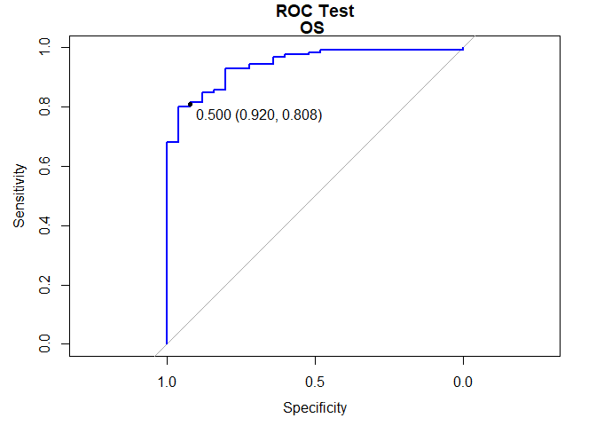

```
Confusion Matrix and Statistics

          Reference
Prediction positive negative
  positive       24       24
  negative        1      101

               Accuracy : 0.8333
                 95% CI : (0.7639, 0.8891)
    No Information Rate : 0.8333
    P-Value [Acc > NIR] : 0.5531

                  Kappa : 0.5614

 Mcnemar's Test P-Value : 1.083e-05

            Sensitivity : 0.9600
            Specificity : 0.8080
         Pos Pred Value : 0.5000
         Neg Pred Value : 0.9902
             Prevalence : 0.1667
         Detection Rate : 0.1600
   Detection Prevalence : 0.3200
      Balanced Accuracy : 0.8840

       'Positive' Class : positive
```

Train with SMOTE

```r
ctrl <- trainControl(method="repeatedcv",number=5,repeats = 3,
                     classProbs=TRUE,summaryFunction = twoClassSummary,sampling = "smote")
model.smt <- learn_model(trainData,ctrl,"SMT ")
cm.smt <- test_model(testData,model.smt,"SMT ")
```

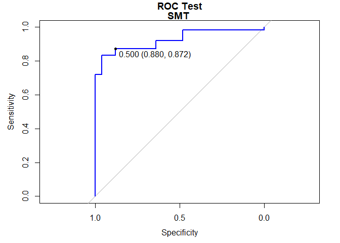

```
Confusion Matrix and Statistics

          Reference
Prediction positive negative
  positive       22       18
  negative        3      107

               Accuracy : 0.86
                 95% CI : (0.794, 0.9112)
    No Information Rate : 0.8333
    P-Value [Acc > NIR] : 0.22462

                  Kappa : 0.5935

 Mcnemar's Test P-Value : 0.00225

            Sensitivity : 0.8800
            Specificity : 0.8560
         Pos Pred Value : 0.5500
         Neg Pred Value : 0.9727
             Prevalence : 0.1667
         Detection Rate : 0.1467
   Detection Prevalence : 0.2667
      Balanced Accuracy : 0.8680

       'Positive' Class : positive
```

## Comparison among models

Summarize models results

```r
# summarize accuracy of models
models <- list(raw = model.raw, us = model.us,
               os = model.os, smt = model.smt)
results <- resamples(models)
summary(results)
```

```
Call:
summary.resamples(object = results)

Models: raw, us, os, smt
Number of resamples: 15

ROC
         Min.   1st Qu.    Median      Mean   3rd Qu.      Max. NA's
raw 0.9151111 0.9373333 0.9417778 0.9497185 0.9613333 0.9942222    0
us  0.8973333 0.9120000 0.9280000 0.9271407 0.9371111 0.9600000    0
os  0.8822222 0.9462222 0.9551111 0.9512296 0.9664444 0.9782222    0
smt 0.8942222 0.9460000 0.9626667 0.9560889 0.9720000 0.9893333    0

Sens
         Min.   1st Qu.    Median      Mean   3rd Qu.      Max. NA's
raw 0.4000000 0.6000000 0.6666667 0.6755556 0.7666667 0.9333333    0
us  0.8000000 0.9333333 1.0000000 0.9511111 1.0000000 1.0000000    0
os  0.9333333 0.9333333 1.0000000 0.9733333 1.0000000 1.0000000    0
smt 0.7333333 0.8333333 0.9333333 0.9066667 1.0000000 1.0000000    0

Spec
         Min.   1st Qu. Median      Mean   3rd Qu.      Max. NA's
raw 0.9066667 0.9466667   0.96 0.9564444 0.9733333 1.0000000    0
us  0.7466667 0.7733333   0.80 0.8017778 0.8333333 0.8666667    0
os  0.7333333 0.7800000   0.80 0.7946667 0.8266667 0.8400000    0
smt 0.7733333 0.8466667   0.88 0.8693333 0.9000000 0.9200000    0
```

Plot comparisons between models

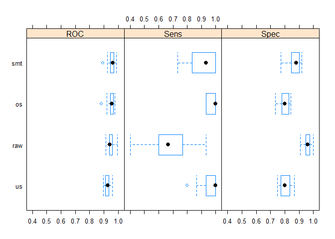

```r
bwplot(results)
```

Similar values in ROC, but bigger differences in sensitivity and specificity.

Final plot with additional metrics

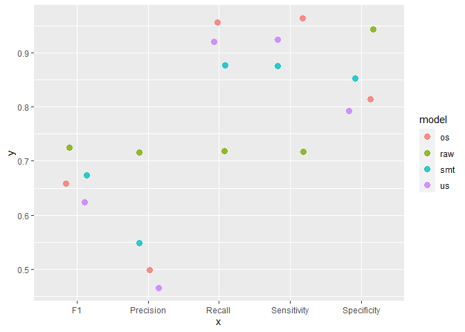

```r
#Carry out a comparison over all imbalanced metrics
comparison <- data.frame(model = names(models),
                         Sensitivity = rep(NA, length(models)),
                         Specificity = rep(NA, length(models)),
                         Precision = rep(NA, length(models)),
                         Recall = rep(NA, length(models)),
                         F1 = rep(NA, length(models)))

for (name in names(models)) {
  cm_model <- get(paste0("cm.", name))

  comparison[comparison$model == name, ] <- filter(comparison, model == name) %>%
    mutate(Sensitivity = cm_model$byClass["Sensitivity"],
           Specificity = cm_model$byClass["Specificity"],
           Precision = cm_model$byClass["Precision"],
           Recall = cm_model$byClass["Recall"],
           F1 = cm_model$byClass["F1"])
}

comparison %>%
  gather(x, y, Sensitivity:F1) %>%
  ggplot(aes(x = x, y = y, color = model)) +
  geom_jitter(width = 0.2, alpha = 0.8, size = 3)
```

## Conclusions

Contamos con un dataset formado por dos atributos numéricos enteros, sobre un total de 600 instancias. Existe un desbalanceo alto (80%) sobre la clase minoritaria.

Una visualización nos muestra que los datos de la clase positiva se encuentran agrupados en una sola zona central del espacio (no hay small disjuncts). Los gráficos nos hacen pensar en dos posibles hipótesis:

1. Por un lado, podemos pensar que la clase negativa se superpone sobre la positiva. Tendríamos puntos ruidosos y fronteras difusas.
2. Por otro, se puede considerar que la clase minoritaria no está distribuída en un único clúster, sino en 4 de ellos en zonas del espacio bastante cercanas, pero aún así separados. Con esta idea en mente, un método de undersampling o de eliminación de ruido que quite las franjas centrales de la clase negativa podría darnos unos muy buenos resultados en training, pero malos en test si realmente esos puntos son representativos.

Dependerá de la semántica del problema y de los atributos ver cuál de estos razonamientos sería más lógico. En principio, puesto que estamos entrenando con KNN, esta distribución de los datos vuelve la tarea un poco más difícil, favoreciendo la clasificación de la clase negativa.

Sobre los resultados, con los valores en crudo comprobamos que la superposición de clases hace difícil obtener un valor alto de sensitivity (en comparación con el resto de métodos). Vemos que por el contrario los valores de specificity son bastante altos, obteniendo una curva ROC engañosamente optimista.

Con el método SMOTE se consigue un buen balanceo de las distintas métricas. Dependerá del objetivo del problema, pero si estuviéramos interesados no solo en detectar la clase minoritaria sino también clasificar bien la positiva, el AUC de SMOTE nos muestra que este podría ser la mejor opción a utilizar. Si por otro lado pudiéramos permitirnos mayor tasa de falsos positivos, random under/over-sampling nos dan mejores resultados.

Pese a ello, de cara a enfrentarnos a este problema de forma real podría ser más interesante optar por una hibridización SMOTE-IPF o SMOTE-ENN de cara a eliminar los puntos ruidosos y limpiar las fronteras tras aplicar el oversampling.

# Activity 2

Load the data

```r
dataset <- ecoli1
dataset
```

| Mcg | Gvh | Lip | Chg | Aac | Alm1 | Alm2 | Class |
| --- | --- | --- | --- | --- | --- | --- | --- |
| 0.49 | 0.29 | 0.48 | 0.5 | 0.56 | 0.24 | 0.35 | negative |
| 0.07 | 0.40 | 0.48 | 0.5 | 0.54 | 0.35 | 0.44 | negative |
| 0.56 | 0.40 | 0.48 | 0.5 | 0.49 | 0.37 | 0.46 | negative |
| 0.59 | 0.49 | 0.48 | 0.5 | 0.52 | 0.45 | 0.36 | negative |
| 0.23 | 0.32 | 0.48 | 0.5 | 0.55 | 0.25 | 0.35 | negative |
| 0.67 | 0.39 | 0.48 | 0.5 | 0.36 | 0.38 | 0.46 | negative |
| 0.29 | 0.28 | 0.48 | 0.5 | 0.44 | 0.23 | 0.34 | negative |
| 0.21 | 0.34 | 0.48 | 0.5 | 0.51 | 0.28 | 0.39 | negative |
| 0.20 | 0.44 | 0.48 | 0.5 | 0.46 | 0.51 | 0.57 | negative |
| 0.42 | 0.40 | 0.48 | 0.5 | 0.56 | 0.18 | 0.30 | negative |

[output cut: 326 more lines]

Summary

```r
summary(dataset)

cat("\n Imbalance Ratio: ")
imbalanceRatio(dataset)
```

```
      Mcg              Gvh         Lip       Chg           Aac
 Min.   :0.0000   Min.   :0.16   0.48:326   0.5:335   Min.   :0.000
 1st Qu.:0.3400   1st Qu.:0.40   1   : 10   1  :  1   1st Qu.:0.420
 Median :0.5000   Median :0.47                        Median :0.495
 Mean   :0.5001   Mean   :0.50                        Mean   :0.500
 3rd Qu.:0.6625   3rd Qu.:0.57                        3rd Qu.:0.570
 Max.   :0.8900   Max.   :1.00                        Max.   :0.880
      Alm1             Alm2             Class
 Min.   :0.0300   Min.   :0.0000   negative:259
 1st Qu.:0.3300   1st Qu.:0.3500   positive: 77
 Median :0.4550   Median :0.4300
 Mean   :0.5002   Mean   :0.4997
 3rd Qu.:0.7100   3rd Qu.:0.7100
 Max.   :1.0000   Max.   :0.9900

 Imbalance Ratio: [1] 0.2972973
```

Preprocess

```r
# Variable Chg has almost zero variance, remove it
dataset$Chg <- NULL

# Change binary factors into numeric
dataset$Lip <- dataset$Lip %>% as.numeric()
```

Train-test split

```r
set.seed(42) #To ensure the same output

#An easy way to create split "data partitions":
trainIndex <- createDataPartition(dataset$Class, p = .75,
                                  list = FALSE,
                                  times = 1)
trainData <- dataset[ trainIndex,]
testData  <- dataset[-trainIndex,]

#Check IR to ensure a stratified partition
imbalanceRatio(trainData)
imbalanceRatio(testData)
```

```
[1] 0.2974359
[1] 0.296875
```

Apply preprocessing with oversample function

```r
# Basic SMOTE
smt <- trainData %>% oversample(method = "SMOTE", ratio = 0.5)

# SMOTE borderline
blsmt <- trainData %>% oversample(method = "BLSMOTE", ratio = 0.5)

# Majority Weighted Minority Oversampling
mwmt <- trainData %>% oversample(method = "MWMOTE", ratio = 0.5)

# ANSMOTE
ansmt <- trainData %>% oversample(method = "ANSMOTE", ratio = 0.5)
```

```
[1] "Borderline-SMOTE done"
[1] "ANS is done"
```

## Train with KNN

```r
ctrl <- trainControl(method="repeatedcv", number=5, repeats = 3,
                     classProbs=TRUE, summaryFunction = twoClassSummary)
```

```r
model.smt <- learn_model(smt, ctrl, "SMT ")
cm.smt <- test_model(testData, model.smt,"SMT ")
```

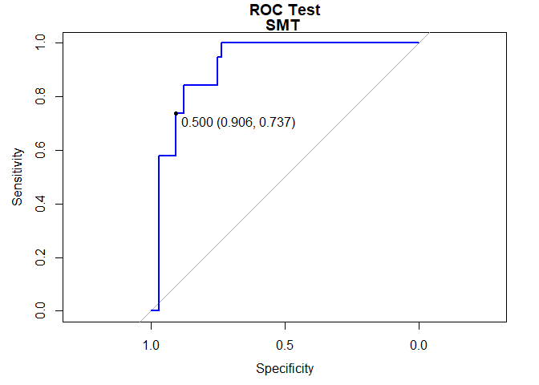

```
Confusion Matrix and Statistics

          Reference
Prediction negative positive
  negative       58        5
  positive        6       14

               Accuracy : 0.8675
                 95% CI : (0.7752, 0.9319)
    No Information Rate : 0.7711
    P-Value [Acc > NIR] : 0.0204

                  Kappa : 0.6314

 Mcnemar's Test P-Value : 1.0000

            Sensitivity : 0.7368
            Specificity : 0.9062
         Pos Pred Value : 0.7000
         Neg Pred Value : 0.9206
             Prevalence : 0.2289
         Detection Rate : 0.1687
   Detection Prevalence : 0.2410
      Balanced Accuracy : 0.8215

       'Positive' Class : positive
```

```r
model.blsmt <- learn_model(blsmt, ctrl, "BLSMT ")
cm.blsmt <- test_model(testData, model.blsmt,"BLSMT ")
```

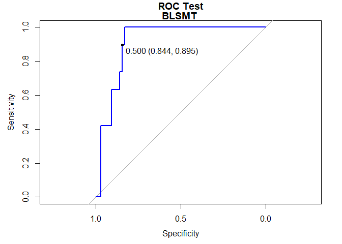

```
Confusion Matrix and Statistics

          Reference
Prediction negative positive
  negative       54        2
  positive       10       17

               Accuracy : 0.8554
                 95% CI : (0.7611, 0.923)
    No Information Rate : 0.7711
    P-Value [Acc > NIR] : 0.03974

                  Kappa : 0.6433

 Mcnemar's Test P-Value : 0.04331

            Sensitivity : 0.8947
            Specificity : 0.8438
         Pos Pred Value : 0.6296
         Neg Pred Value : 0.9643
             Prevalence : 0.2289
         Detection Rate : 0.2048
   Detection Prevalence : 0.3253
      Balanced Accuracy : 0.8692

       'Positive' Class : positive
```

```r
model.mwmt <- learn_model(mwmt, ctrl, "MWSMT ")
cm.mwmt <- test_model(testData, model.mwmt,"MWSMT ")
```

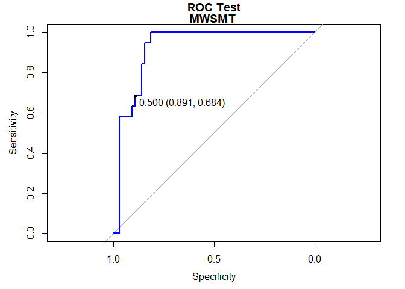

```
Confusion Matrix and Statistics

          Reference
Prediction negative positive
  negative       57        6
  positive        7       13

               Accuracy : 0.8434
                 95% CI : (0.7471, 0.9139)
    No Information Rate : 0.7711
    P-Value [Acc > NIR] : 0.07109

                  Kappa : 0.5644

 Mcnemar's Test P-Value : 1.00000

            Sensitivity : 0.6842
            Specificity : 0.8906
         Pos Pred Value : 0.6500
         Neg Pred Value : 0.9048
             Prevalence : 0.2289
         Detection Rate : 0.1566
   Detection Prevalence : 0.2410
      Balanced Accuracy : 0.7874

       'Positive' Class : positive
```

```r
model.ansmt <- learn_model(ansmt, ctrl, "ANSMT ")
cm.ansmt <- test_model(testData, model.ansmt,"ANSMT ")
```

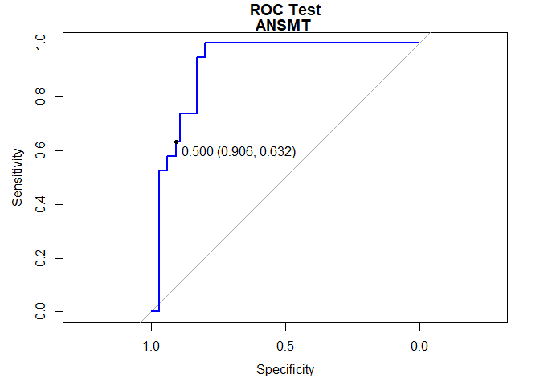

```
Confusion Matrix and Statistics

          Reference
Prediction negative positive
  negative       58        7
  positive        6       12

               Accuracy : 0.8434
                 95% CI : (0.7471, 0.9139)
    No Information Rate : 0.7711
    P-Value [Acc > NIR] : 0.07109

                  Kappa : 0.548

 Mcnemar's Test P-Value : 1.00000

            Sensitivity : 0.6316
            Specificity : 0.9062
         Pos Pred Value : 0.6667
         Neg Pred Value : 0.8923
             Prevalence : 0.2289
         Detection Rate : 0.1446
   Detection Prevalence : 0.2169
      Balanced Accuracy : 0.7689

       'Positive' Class : positive
```

Summarize models results

```r
models <- list(smt = model.smt, blsmt = model.blsmt,
               mwmt = model.mwmt, ansmt = model.ansmt)
results <- resamples(models)
summary(results)
```

```
Call:
summary.resamples(object = results)

Models: smt, blsmt, mwmt, ansmt
Number of resamples: 15

ROC
           Min.   1st Qu.    Median      Mean   3rd Qu.      Max. NA's
smt   0.9136302 0.9653846 0.9743590 0.9698718 0.9832321 0.9961538    0
blsmt 0.8814103 0.9349359 0.9576923 0.9512056 0.9744096 0.9925776    0
mwmt  0.9129555 0.9592949 0.9662618 0.9654296 0.9775641 0.9885290    0
ansmt 0.9392713 0.9554487 0.9703104 0.9707422 0.9845816 0.9974359    0

Sens
           Min.   1st Qu.    Median      Mean   3rd Qu.      Max. NA's
smt   0.8461538 0.9230769 0.9487179 0.9367521 0.9487179 1.0000000    0
blsmt 0.7948718 0.8461538 0.8974359 0.8923077 0.9487179 0.9487179    0
mwmt  0.8461538 0.9102564 0.9487179 0.9264957 0.9487179 0.9743590    0
ansmt 0.8717949 0.9102564 0.9487179 0.9384615 0.9743590 0.9743590    0

Spec
           Min.   1st Qu.    Median      Mean   3rd Qu. Max. NA's
smt   0.7000000 0.8460526 0.9000000 0.8714035 0.9473684 1.00    0
blsmt 0.8421053 0.8723684 0.9000000 0.9214035 0.9750000 1.00    0
mwmt  0.7894737 0.8421053 0.8500000 0.8845614 0.9250000 1.00    0
ansmt 0.7894737 0.8500000 0.8947368 0.8742105 0.9000000 0.95    0
```

Plot results comparison between models

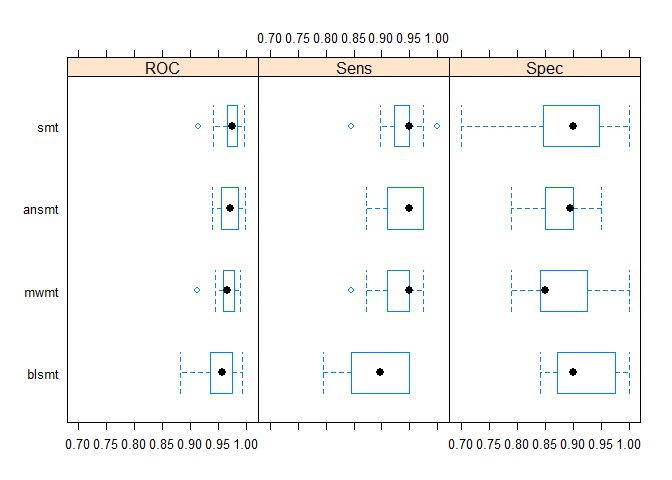

```r
bwplot(results)
```

# Visualize the data distribution between original and preprocess data.

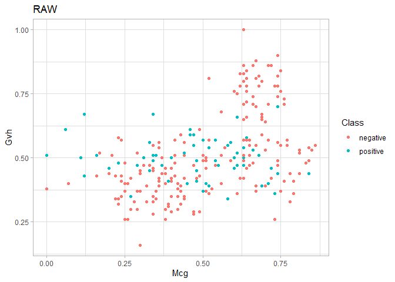

```r
trainData %>%
  ggplot(aes(x=Mcg, y=Gvh, color=Class)) +
    geom_point() +
    labs(title="RAW") +
    theme_light()
```

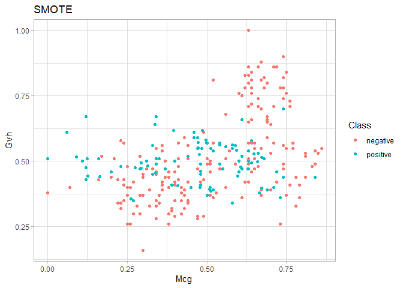

```r
smt %>%
  ggplot(aes(x=Mcg, y=Gvh, color=Class)) +
    geom_point() +
    labs(title="SMOTE") +
    theme_light()
```

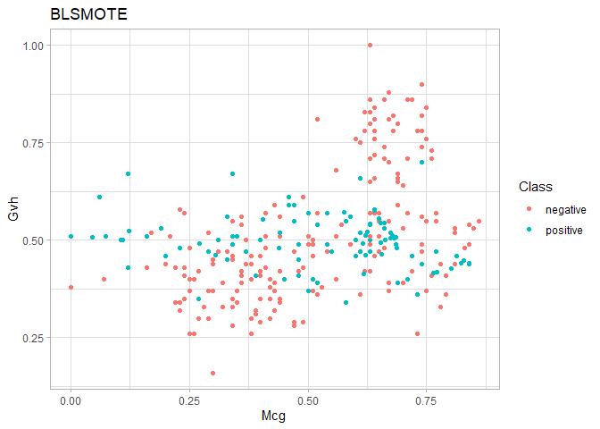

```r
blsmt %>%
  ggplot(aes(x=Mcg, y=Gvh, color=Class)) +
    geom_point() +
    labs(title="BLSMOTE") +
    theme_light()
```

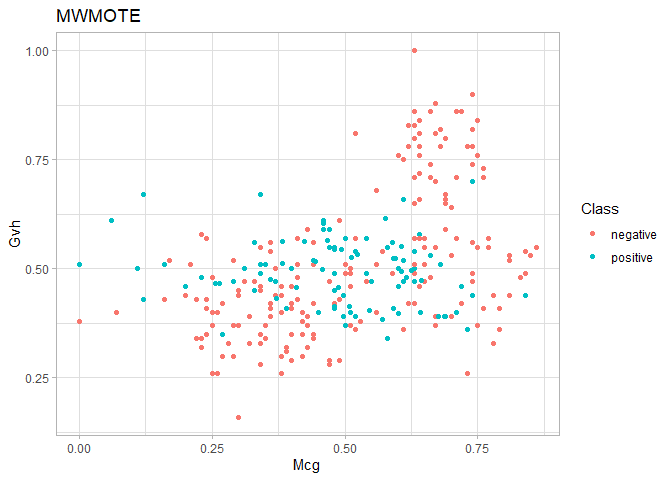

```r
mwmt %>%
  ggplot(aes(x=Mcg, y=Gvh, color=Class)) +
    geom_point() +
    labs(title="MWMOTE") +
    theme_light()
```

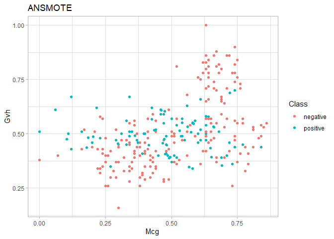

```r
ansmt %>%
  ggplot(aes(x=Mcg, y=Gvh, color=Class)) +
    geom_point() +
    labs(title="ANSMOTE") +
    theme_light()
```

t-SNE

```r
tsne_out <- trainData %>% select(-Class) %>% tsne()
```

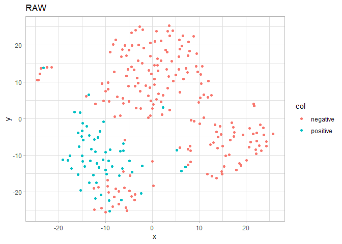

```r
data.frame(x = tsne_out[,1],
           y = tsne_out[,2],
           col = trainData$Class) %>%
  ggplot() +
    geom_point(aes(x=x, y=y, color=col)) +
    labs(title="RAW") +
    theme_light()
```

```r
tsne_out <- smt %>% select(-Class) %>% tsne()
```

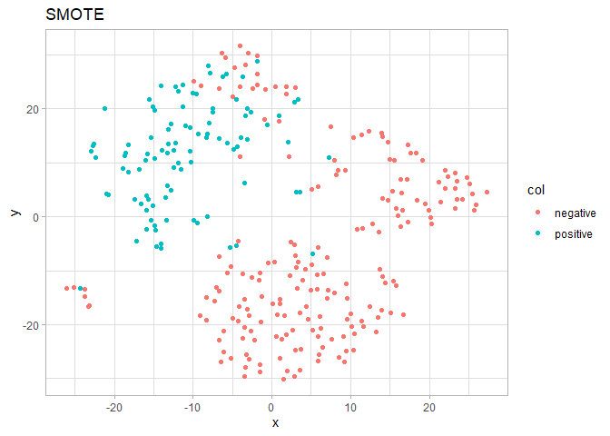

```r
data.frame(x = tsne_out[,1],
           y = tsne_out[,2],
           col = smt$Class) %>%
  ggplot() +
    geom_point(aes(x=x, y=y, color=col)) +
    labs(title="SMOTE") +
    theme_light()
```

```r
tsne_out <- blsmt %>% select(-Class) %>% tsne()
```

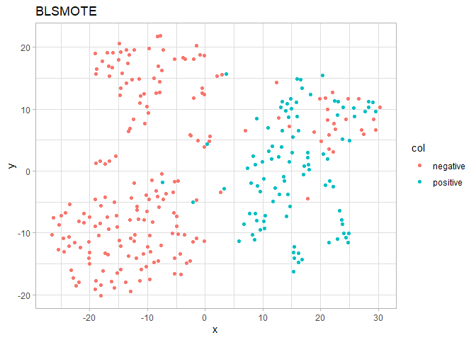

```r
data.frame(x = tsne_out[,1],
           y = tsne_out[,2],
           col = blsmt$Class) %>%
  ggplot() +
    geom_point(aes(x=x, y=y, color=col)) +
    labs(title="BLSMOTE") +
    theme_light()
```

```r
tsne_out <- mwmt %>% select(-Class) %>% tsne()
```

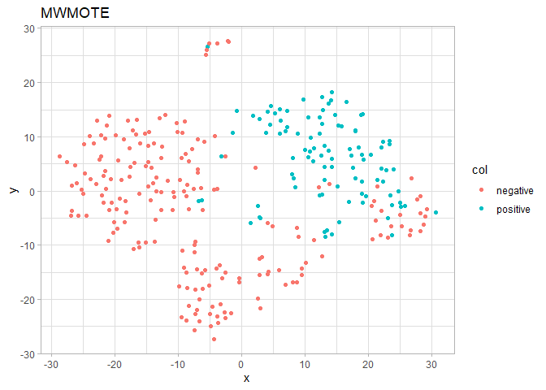

```r
data.frame(x = tsne_out[,1],
           y = tsne_out[,2],
           col = mwmt$Class) %>%
  ggplot() +
    geom_point(aes(x=x, y=y, color=col)) +
    labs(title="MWMOTE") +
    theme_light()
```

```r
tsne_out <- ansmt %>% select(-Class) %>% tsne()
```

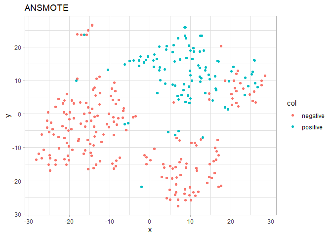

```r
data.frame(x = tsne_out[,1],
           y = tsne_out[,2],
           col = ansmt$Class) %>%
  ggplot() +
    geom_point(aes(x=x, y=y, color=col)) +
    labs(title="ANSMOTE") +
    theme_light()
```

Pie plots

```r
plot_pie <- function(y, method="") {
  n_classes <- c(sum(y=="positive"),sum(y=="negative"))
  pct <- round(n_classes/sum(n_classes)*100,digits=2)

  # lbls <- levels(dataset$Class)
  lbls <- c("positive", "negative")
  lbls <- paste(lbls, pct) # add percents to labels
  lbls <- paste(lbls,"%",sep="") # ad % to labels

  pie(n_classes,labels = lbls, main=paste("Class distribution", method))
}
```

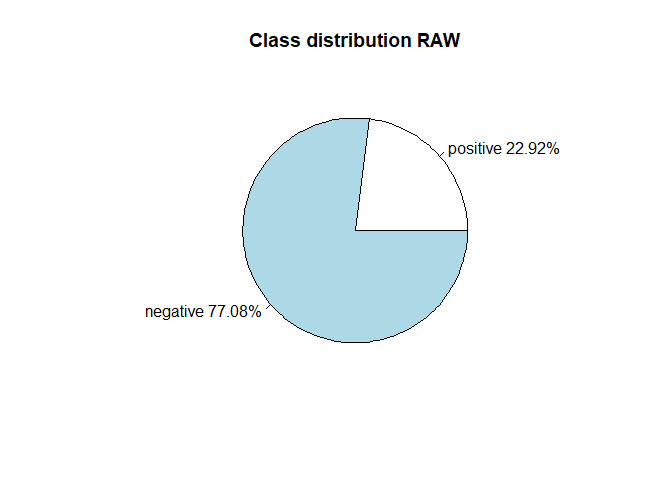

```r
plot_pie(trainData$Class, "RAW")
```

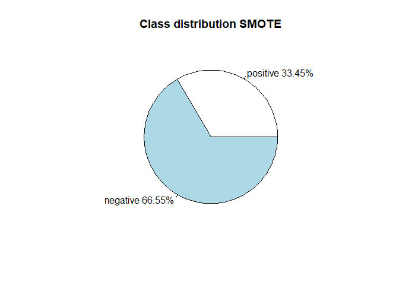

```r
plot_pie(smt$Class, "SMOTE")
```

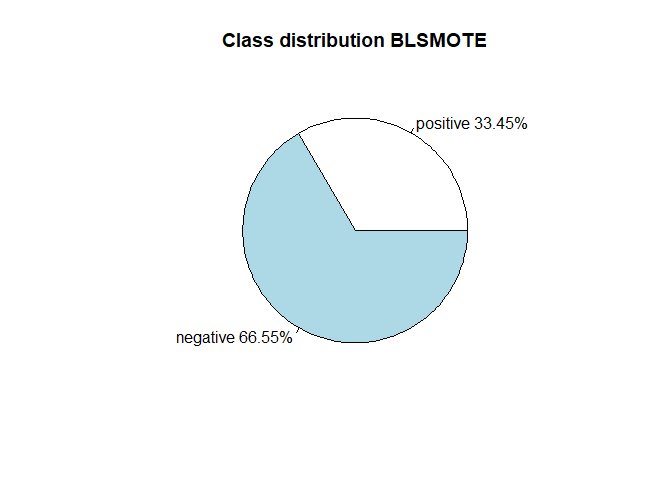

```r
plot_pie(blsmt$Class, "BLSMOTE")
```

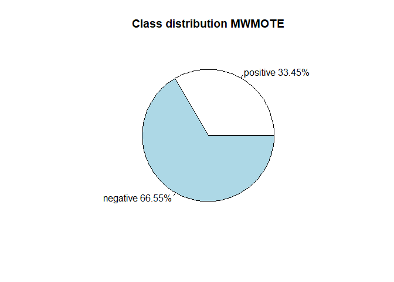

```r
plot_pie(mwmt$Class, "MWMOTE")
```

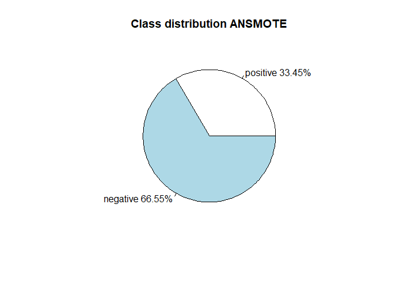

```r
plot_pie(ansmt$Class, "ANSMOTE")
```

Sobre el aprendizaje, en general se obtienen mejores resultados para SMOTE, pero a costa de una mayor variabilidad en specificity. Por otro lado, ANSMOTE y MWMOTE se comportan de manera muy similar, y podemos ver en las gráficas y en los plost de tsne que los datasets resultantes se asemejan bastante. Finalmente, BLSMOTE parece obtener resultados más inestables en KNN, pero en media su comportamiento en specificity es muy bueno.